# Midterm 2

Author

Ilana Berlin

Published

November 16, 2025

```r
library(tidyverse)
library(readxl)
library(gt)
summer_school <- read.csv("summer_school.csv")
cupid <- read.csv("cupid.csv")
```

## Problem 1

> Tidying the data as needed, recreate the following plot as closely as possible.

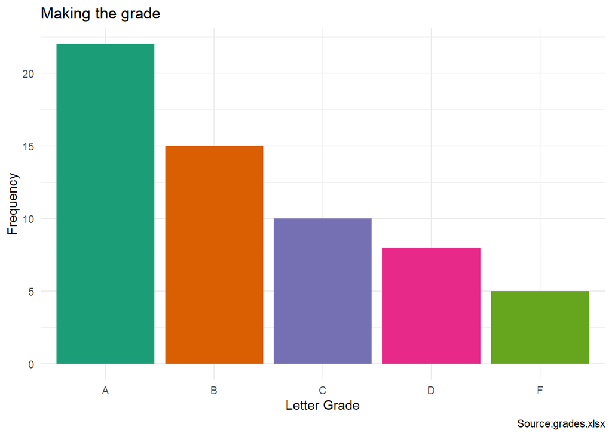

```r
summer_tidy <- summer_school %>%
  pivot_longer(c(term1, term2),
               names_to = "Term",
               names_prefix = "term",
               values_to = "grade",
               values_drop_na = TRUE)

summer_tidy %>%
  ggplot(aes(x = grade,
             fill = grade)) +
  geom_bar(show.legend = FALSE) +
  theme_minimal() +
  scale_fill_brewer(palette = "Dark2") +
  labs(x = "Letter Grade",
       y = "Frequency",
       title = "Making the grade",
       caption = "Source:grades.xlsx")
```

## Problem 2

> The high school claims that the average GPA of students taking summer school classes is 3.1. Is this claim reasonable in light of this sample data? Follow all best practices from class.

$H_0$: The average GPA of students taking summer school classes is 3.1

$H_a$: The average GPA of students taking summer school classes is *not* 3.1

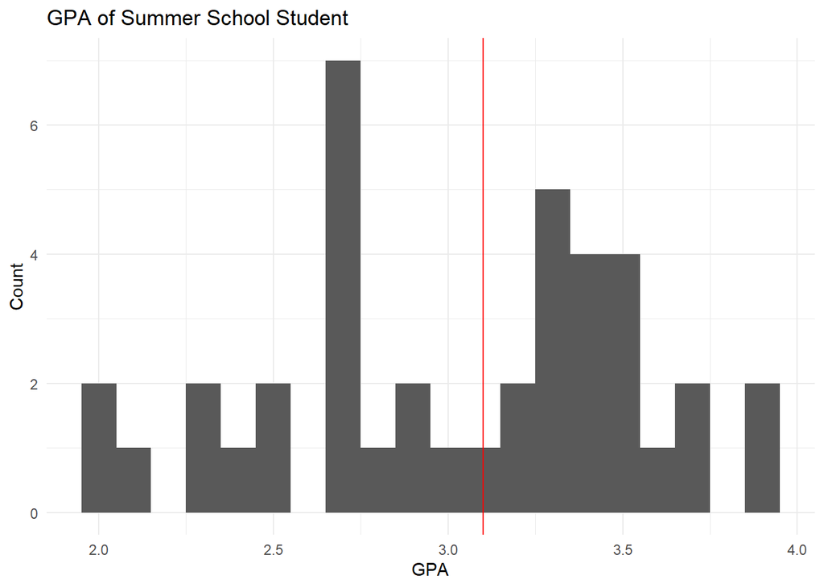

```r
summer_school %>%
  ggplot(aes(x = gpa)) +
  geom_histogram(binwidth = 0.1) +
  geom_vline(xintercept = 3.1,
             color = "red") +
  theme_minimal() +
  labs(x = "GPA",
       y = "Count",
       title = "GPA of Summer School Student")
```

```r
t.test(summer_school$gpa,
       mu = 3.1 )
```

```
    One Sample t-test

data:  summer_school$gpa
t = -0.91614, df = 39, p-value = 0.3652
alternative hypothesis: true mean is not equal to 3.1
95 percent confidence interval:
 2.859412 3.190588
sample estimates:
mean of x
    3.025
```

If the average GPA claimed by the high school is true, then data such as the sample data above would appear around 36.5% of the time. There is not enough evidence to reject the claim of the high school. In light of our data, it would be reasonable to say that the average GPA of student who take summer school classes is 3.1.

## Problem 3

> Recreate the following table as closely as possible.

```r
summer_tidy %>%
  group_by(Term) %>%
  summarise(Number= n(),
            "DF Rate" = sum(grade %in% c("D","F"))/ n() ) %>%
  gt()
```

| Term | Number | DF Rate |
| --- | --- | --- |
| 1 | 40 | 0.10 |
| 2 | 20 | 0.45 |

## Problem 4

> Does it seem that body type and drug use are related? Consider only the five most common body types and only people that answered these questions. Generate a plot and a table, both useful and attractive, then write a few sentences explaining your findings and reasoning.

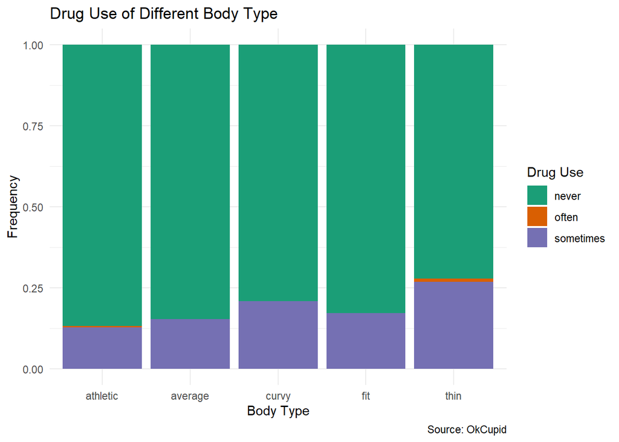

```r
#| label: drug body type figure
#| fig-alt: a bar chart showing the drug use of people with different body types


top_body <- cupid %>%
  filter(!is.na(body_type)) %>%
  group_by(body_type) %>%
  summarise(count = n()) %>%
  arrange(desc(count)) %>%
  head(n = 5) %>%
  pull(body_type)


cupid_body_drug <- cupid %>%
  filter(body_type %in% top_body,
         !is.na(drugs))

cupid_body_drug %>%
  ggplot(aes(x = body_type, #order by frequency - claude
             fill = drugs)) +
  geom_bar(position = 'fill') +
  theme_minimal() +
  scale_fill_brewer(palette = "Dark2") +
  labs(x = "Body Type",
       y = "Frequency",
       fill = "Drug Use",
       title = "Drug Use of Different Body Type",
       caption = "Source: OkCupid")
```

```r
cupid_body_drug %>%
  group_by(body_type,
           drugs) %>%
  summarise(count = n()) %>%
  mutate(percent = round(count/ sum(count), 3) * 100) %>%
  gt(row_group_as_column = TRUE) %>%
  tab_header(title = "Drug use by Body Type")
```

Drug use by Body Type

|  | drugs | count | percent |
| --- | --- | --- | --- |
| athletic | never | 197 | 86.8 |
|  | often | 1 | 0.4 |
|  | sometimes | 29 | 12.8 |
| average | never | 238 | 84.7 |
|  | sometimes | 43 | 15.3 |
| curvy | never | 72 | 79.1 |
|  | sometimes | 19 | 20.9 |
| fit | never | 194 | 82.9 |
|  | sometimes | 40 | 17.1 |
| thin | never | 70 | 72.2 |
|  | often | 1 | 1.0 |
|  | sometimes | 26 | 26.8 |

## Problem 5

> According to Gallup, 3.4% of U.S. adults identify as gay and 5.2% identify as bisexual. Assume the remaining 91.4% are straight (which isn’t really true). Is the `cupid` data set consistent with this information? Follow all best practices from class.

$H_0$: The ratios of sexual orientation match the claims made by Gallup, so 3.4% of adults are gay, 5.2% are bisexual, and 91.4% are straight.

$H_a$: The ratios of sexual orientation do not match the claims made by Gallup

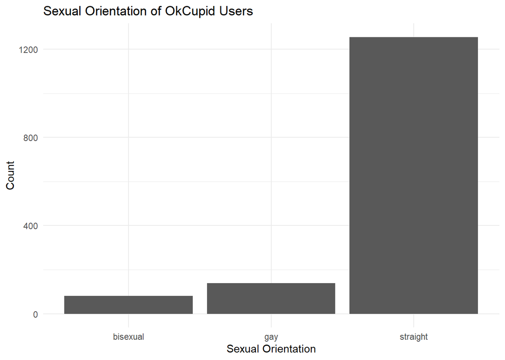

```r
cupid %>%
  ggplot(aes(x = orientation)) +
  geom_bar() +
  theme_minimal() +
  labs(x = "Sexual Orientation",
       y = "Count",
       title = "Sexual Orientation of OkCupid Users")
```

```r
table <- table(cupid$orientation)
chisq.test(table,
           p = c(0.052, 0.034, 0.914))
```

```
    Chi-squared test for given probabilities

data:  table
X-squared = 160.68, df = 2, p-value < 2.2e-16
```

## Problem 6

> Use `separate`, `case_when`, and core tools from class to obtain accurate counts of various individual ethnicities represented in this data set. Generate an attractive plot showing the 6 most common responses.

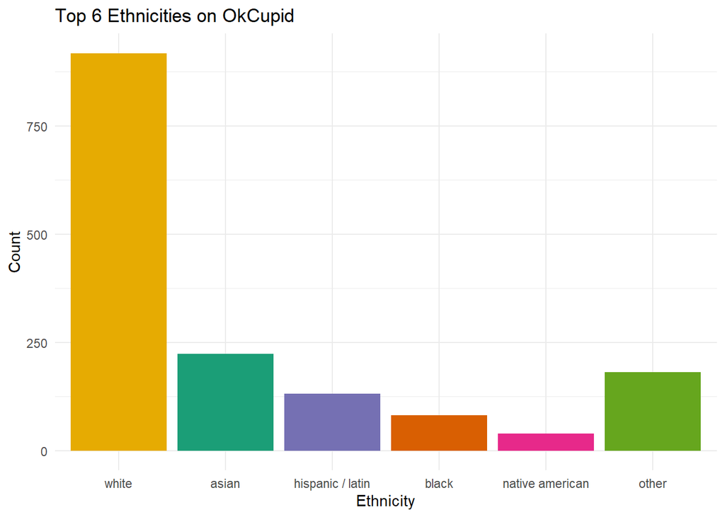

```r
cupid_long <- cupid %>%
  filter(!is.na(ethnicity)) %>%
 separate_longer_delim(ethnicity, #from the tidyr package
                       delim = ',') %>%
  mutate(ethnicity = str_squish(ethnicity)) #remove whitespace (from stringr)

top_eth <- cupid_long %>%
  group_by(ethnicity) %>%
  summarise(count = n()) %>% #this feels wrong - people are being double counted
  arrange(desc(count)) %>%
  head(n=6) %>%
  pull(ethnicity)

cupid_long %>%
  mutate( ethnicity = case_when(
    ethnicity %in% top_eth ~ ethnicity,
    .default = "other" #set to other when not in the top 6
  )) %>%
  group_by(ethnicity) %>%
  summarise(count = n()) %>% #this feels wrong - people are being double counted
  arrange(desc(count)) %>%
  slice_head(n = 6) %>%
  ggplot(aes(x = fct_reorder(ethnicity, desc(count)) %>%
                               fct_relevel("other", after = Inf), #move other to the end with help from claude
             fill = ethnicity,
             y = count)) +
  geom_col(show.legend = FALSE) +
  theme_minimal() +
  scale_fill_brewer(palette = "Dark2") +
  labs(x = "Ethnicity",
       y = "Count",
       title = "Top 6 Ethnicities on OkCupid")
```

## Footnotes

[^1]: [Verhaegen AA, Van Gaal LF. *Drugs That Affect Body Weight, Body Fat Distribution, and Metabolism* **2019**](https://www.ncbi.nlm.nih.gov/books/NBK537590/)